# Temperatura JP x CG

```r
climas = read_csv(here::here("data/clima_cg_jp-semanal.csv"),
                  col_types = "cTdddddd")

glimpse(climas)
```

```
## Observations: 2,748
## Variables: 8
## $ cidade <chr> "Campina Grande", "Campina Grande", "Campina Grande", "Campi...
## $ semana <dttm> 1992-12-27, 1993-01-03, 1993-01-10, 1993-01-31, 1993-02-07,...
## $ tmedia <dbl> 26.13333, 26.11905, 25.76667, 25.74000, 26.31429, 26.28571, ...
## $ tmax   <dbl> 30.4, 32.4, 32.2, 32.0, 32.7, 32.7, 32.3, 32.3, 32.1, 31.2, ...
## $ tmin   <dbl> 20.7, 19.3, 19.7, 19.9, 19.6, 20.0, 20.4, 21.2, 19.0, 19.0, ...
## $ chuva  <dbl> 0.0, 0.0, 0.0, 0.4, 0.3, 0.0, 4.9, 0.0, 0.0, 6.1, 0.4, 1.2, ...
## $ mes    <dbl> 12, 1, 1, 1, 2, 2, 2, 2, 10, 11, 11, 11, 11, 12, 12, 12, 12,...
## $ ano    <dbl> 1992, 1993, 1993, 1993, 1993, 1993, 1993, 1993, 1993, 1993, ...
```

## Temperatura

### Onde é mais quente?

Para responder esta questão iremos considerar a média anual de temperatura de cada cidade com base, a priori, na variável tmedia (temperatura média semanal). Sendo assim, temos:

```r
#descobrir quantas cidades diferentes estão presentes na base de dados.
unique(climas$cidade)
```

```
## [1] "Campina Grande" "João Pessoa"
```

```r
#separar a base de acordo com as duas cidades.
cg = climas %>% filter(cidade == "Campina Grande")
jp = climas %>% filter(cidade == "João Pessoa")
```

```r
#Verificar quantidade de amostras para cada ano
unique(cg$ano)
```

```
##  [1] 1992 1993 1994 1995 1996 1997 1998 1999 2000 2001 2002 2003 2004 2005 2006
## [16] 2007 2008 2009 2010 2011 2012 2013 2014 2015 2016 2017 2018 2019
```

```r
unique(jp$ano)
```

```
##  [1] 1987 1988 1990 1991 1992 1993 1994 1995 1996 1997 1998 1999 2000 2001 2002
## [16] 2003 2004 2005 2006 2007 2008 2009 2010 2011 2012 2013 2014 2015 2016 2017
## [31] 2018 2019
```

```r
climas %>% group_by(cidade) %>% filter(ano ==1992) %>%count(cidade)
```

```
## # A tibble: 2 x 2
## # Groups:   cidade [2]
##   cidade             n
##   <chr>          <int>
## 1 Campina Grande     1
## 2 João Pessoa       52
```

Como não há registros da temperatura de Campina Grande entre os anos de 1987 e 1991, e há apenas 1 registro do ano de 1992, para está questão vamos considerar apenas registros do ano 1993 em diante.

```r
#computar média de temperatura anual de cada cidade

df.mean.temp = climas %>%  filter(ano >=1993) %>% group_by(cidade,ano) %>%
    summarise(temperatura.media = mean(tmedia))

head(df.mean.temp)
```

```
## # A tibble: 6 x 3
## # Groups:   cidade [1]
##   cidade           ano temperatura.media
##   <chr>          <dbl>             <dbl>
## 1 Campina Grande  1993              26.0
## 2 Campina Grande  1994              25.8
## 3 Campina Grande  1995              24.7
## 4 Campina Grande  1996              24.5
## 5 Campina Grande  1997              24.6
## 6 Campina Grande  1998              25.5
```

```r
tail(df.mean.temp)
```

```
## # A tibble: 6 x 3
## # Groups:   cidade [1]
##   cidade        ano temperatura.media
##   <chr>       <dbl>             <dbl>
## 1 João Pessoa  2014              27.7
## 2 João Pessoa  2015              27.9
## 3 João Pessoa  2016              28.1
## 4 João Pessoa  2017              28.0
## 5 João Pessoa  2018              28.0
## 6 João Pessoa  2019              29.2
```

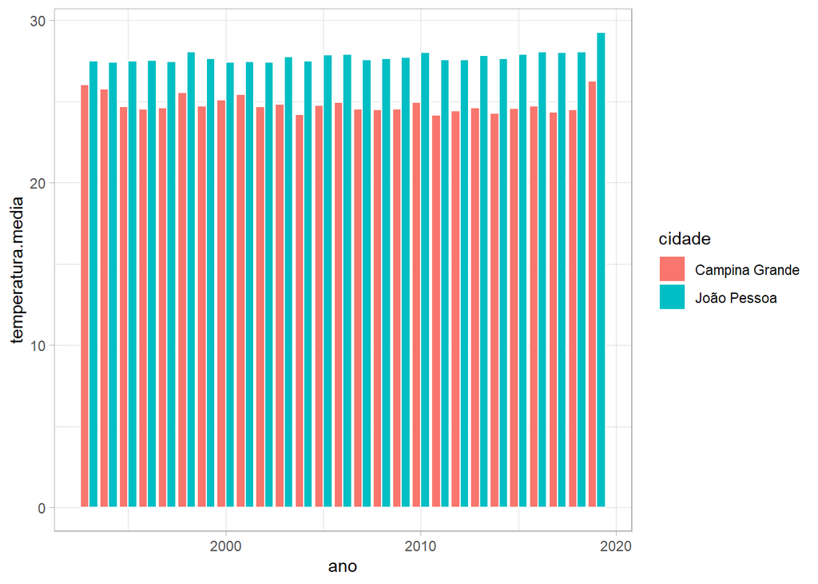

```r
#Plotar gráfico de barra comparando média de temperatura ano a ano de cada cidade
ggplot(df.mean.temp, aes(x=ano, y=temperatura.media, fill=cidade)) +
  geom_bar(stat="identity", color="white", position = "dodge")+
    theme_light()
```

```r
ggsave("temp_media_anual_cg_jp.png")
```

Sendo assim, com base no gráfico de temperatura média anual de cada cidade plotado acima, podemos concluir que, a partir de 1993, João Pessoa vem apresentando uma temperatura anual mais elevada que Campina Grande.

### As temperaturas máximas semanais (o pico do calor) são tão diferentes quanto as médias? Mais?

Para melhor entender a diferença entre essas duas métricas, vamos plotar a distribuição de seus valores.

A seguir temos um histograma representando as medições de temperatuda média.

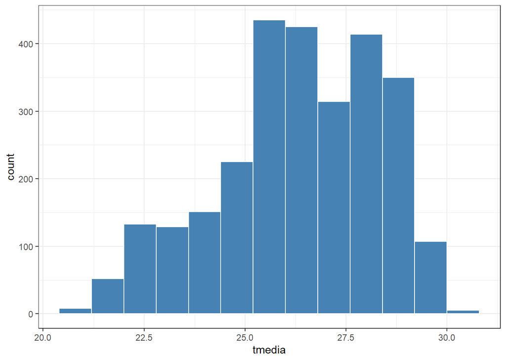

```r
ggplot(climas, aes(x = tmedia)) +geom_histogram(binwidth = 0.8,color= "white", fill = "steelblue")
```

Enquanto que o próximo histograma representa a distribuição da temperatura máxima.

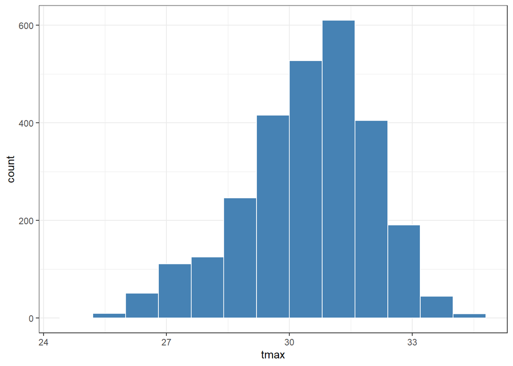

```r
ggplot(climas, aes(x = tmax)) +geom_histogram(binwidth = 0.8,color= "white", fill = "steelblue")
```

### Quais os meses mais quentes e mais frios?

Para responder esta questão, iremos novamente considerar a média da variável tmedia, porém desta vez não faremos distinção entre as cidades, agrupando os dados apenas pelos meses. Sendo assim, temos:

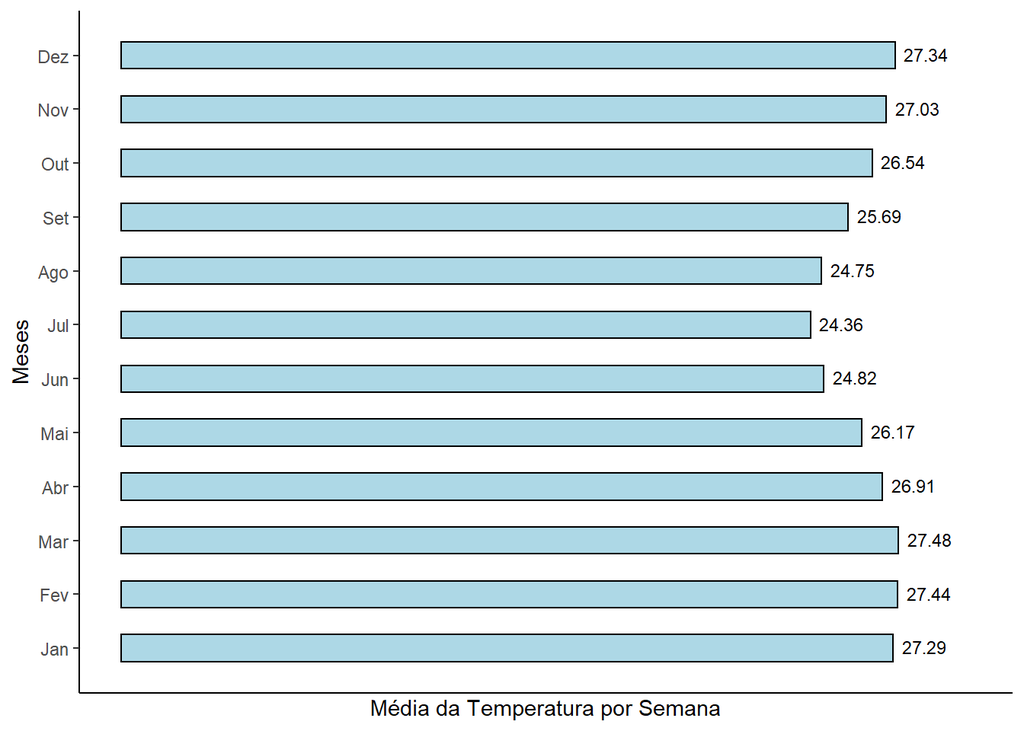

```r
meses = c("Jan","Fev","Mar","Abr","Mai","Jun","Jul","Ago","Set","Out","Nov","Dez")
# Calcular e ordenar temperatura média por mês
df.mean.temp.month = climas %>% group_by(mes) %>% summarise(tmedia.mes = mean(tmedia)) %>% arrange(mes)

#plotar média bar chart

ggplot(df.mean.temp.month, aes(y=mes, x=tmedia.mes)) +
  geom_bar(stat="identity", color="black", fill = "lightblue", position = "dodge", width = 0.5)+
    theme_classic()+
    theme( panel.grid.major = element_blank(),panel.grid.minor = element_blank())+
    scale_x_continuous(name = "Média da Temperatura por Semana", breaks = NULL,limits = c(0,30)) +
    scale_y_continuous(name="Meses", labels = meses, breaks = seq(1,12))+
    geom_text(aes(label=round(tmedia.mes,digits = 2)),vjust = 0.4,hjust=-0.2, color="black", size=3)+


ggsave("temp_media_mes.pdf",width = 6,height = 4)
```

Ordenando de maneira decrescente os dados apresentados no gráfico acima, temos que os 3 meses mais quentes são: Março(3), Fevereiro(2) e Dezembro(12).

```r
head(df.mean.temp.month, 3)
```

```
## # A tibble: 3 x 2
##     mes tmedia.mes
##   <dbl>      <dbl>
## 1     1       27.3
## 2     2       27.4
## 3     3       27.5
```

Enquanto que os meses mais frios são: Julho(7), Agosto(8) e Junho(6)

```r
tail(df.mean.temp.month, 3)
```

```
## # A tibble: 3 x 2
##     mes tmedia.mes
##   <dbl>      <dbl>
## 1    10       26.5
## 2    11       27.0
## 3    12       27.3
```

### Qual foi o São João mais frio de CG que está nos nossos dados?

Tendo que o São João ocorre no dia 24/06 e que a data da amostras corresponde a semana que passou (último dia), por exemplo, 10/01/1993 corresponde ao período 04/01 até 10/01 (intervalo=(D1,D2]),para responder essa pergunta vamos considerar todos os registros entre os dia 24/06 até 30/06.

```r
#climas
saoJoao = climas %>% filter(month(semana) == 6) %>%
  filter(day(semana)>=24 & day(semana)<=30) %>%
  filter(cidade =="Campina Grande")

saoJoao
```

```
## # A tibble: 22 x 8
##    cidade         semana              tmedia  tmax  tmin chuva   mes   ano
##    <chr>          <dttm>               <dbl> <dbl> <dbl> <dbl> <dbl> <dbl>
##  1 Campina Grande 1995-06-25 00:00:00   21.9  27.5  18.2  67.7     6  1995
##  2 Campina Grande 1996-06-30 00:00:00   22.2  27.2  16.7   6.8     6  1996
##  3 Campina Grande 1997-06-29 00:00:00   22.3  27    17.9  44.2     6  1997
##  4 Campina Grande 1998-06-28 00:00:00   24.3  28.9  17.8   0.3     6  1998
##  5 Campina Grande 1999-06-27 00:00:00   23.0  27.7  17.3  18.1     6  1999
##  6 Campina Grande 2002-06-30 00:00:00   21.6  26.7  17.1  25.1     6  2002
##  7 Campina Grande 2003-06-29 00:00:00   22.2  27.2  16.1  20       6  2003
##  8 Campina Grande 2004-06-27 00:00:00   21.8  26.4  17.4  31.4     6  2004
##  9 Campina Grande 2005-06-26 00:00:00   22.0  27    17.4  31.2     6  2005
## 10 Campina Grande 2006-06-25 00:00:00   22.2  26.9  18.5  39.8     6  2006
## # ... with 12 more rows
```

Sendo assim, como base na temperatura média semanal, temos que o São João mais frio de Campina Grande, foi registrado entre os dias 29 e 23 de Junho de 2008, tendo uma temperatura média de 21,34ºC, como podemos ver na seleção abaixo.

```r
saoJoao %>% arrange(tmedia) %>% head(1)
```

```
## # A tibble: 1 x 8
##   cidade         semana              tmedia  tmax  tmin chuva   mes   ano
##   <chr>          <dttm>               <dbl> <dbl> <dbl> <dbl> <dbl> <dbl>
## 1 Campina Grande 2008-06-29 00:00:00   21.3  25.3  17.1  66.8     6  2008
```

Por outro lado, considerando o pico mínimo de temperatuda, temos que a temperatura mais baixa do São João de Campina Grande foi 16,1ºC, sendo registrada entre os dias 29 e 23 de Junho de 2003.

```r
saoJoao %>% arrange(tmin) %>% head(1)
```

```
## # A tibble: 1 x 8
##   cidade         semana              tmedia  tmax  tmin chuva   mes   ano
##   <chr>          <dttm>               <dbl> <dbl> <dbl> <dbl> <dbl> <dbl>
## 1 Campina Grande 2003-06-29 00:00:00   22.2  27.2  16.1    20     6  2003
```

## Chuva

### Quanto chove por semana em JP e CG?

Para responder está pergunta vamos calcular a média da quantidade de chuva semanal de cada cidade.

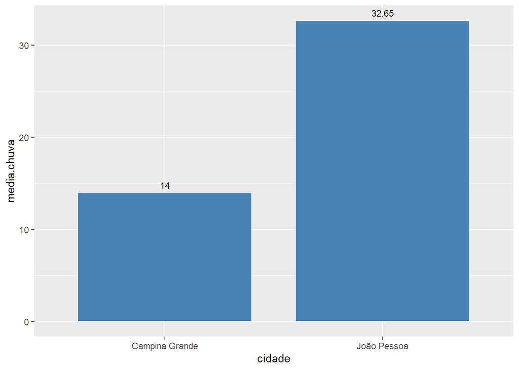

```r
#média da coluna chuva agrupada para cidade
df.mean.chuva = climas %>% group_by(cidade) %>%
    summarise(media.chuva = mean(chuva))

ggplot(df.mean.chuva, aes(x=cidade, y=media.chuva)) +
  geom_bar(stat="identity", fill="steelblue",color="white", width = 0.8)+
    theme_gray()+
    geom_text(aes(label=round(media.chuva,digits = 2)), vjust=-0.6, color="black", size=3)
```

De acordo com o gráfico apresentado acima, temos que, considerando um período anual, Campina Grande apresenta uma média de 14mm de chuva semanalmente, enquanto que João Pessoa tem em média 32,65mm de chuva por semana.

### Como é a distribuição do volume de chuvas por semana em JP e CG? A chuva varia mais ou menos que a temperatura? O formato da distribuição é igual?

Para entender a distribuição do volume de chuva de cada cidade, primeiro é preciso tratar os dados disponíveis. Sendo assim:

```r
climas %>% select(,chuva) %>% summary()
```

```
##      chuva
##  Min.   :  0.00
##  1st Qu.:  1.40
##  Median :  8.80
##  Mean   : 24.34
##  3rd Qu.: 31.10
##  Max.   :351.60
```

Analisando o 3º quartil e o valor máximo, podemos perceber que existem outliers nos dados, então vamos analisar a quantidade de amostras com um valor muito acima da média para saber se podemos excluí-los sem resultar em uma grande perda de dados.

```r
climas %>% filter( chuva >=300) %>% nrow()
```

```
## [1] 1
```

```r
climas %>% filter( chuva >=200) %>% nrow()
```

```
## [1] 13
```

```r
climas %>% filter( chuva >=175) %>% nrow() #max/2
```

```
## [1] 28
```

```r
climas %>% nrow()
```

```
## [1] 2748
```

Considerando a metade do valor máximo (175,5) como valor de corte, vamos excluir da análise 28 amostras, o que corresponde a aprximadamente 1% dos dados. Então, temos o seguinte histograma:

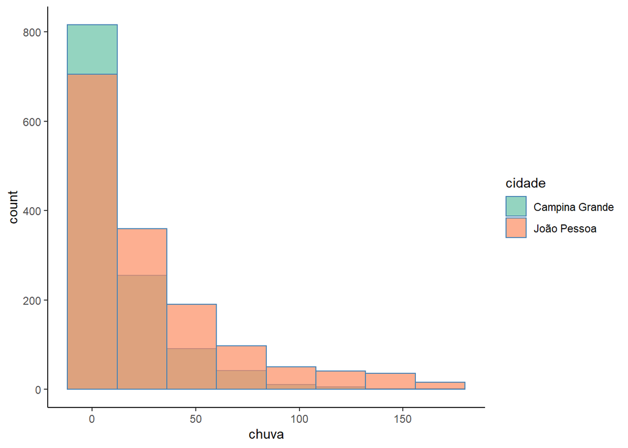

```r
climas.corte = climas %>% filter(chuva <=175)

#tamanho da barra correspondente a média das amostras
ggplot(climas.corte, aes(x = chuva, fill=cidade))+
    geom_histogram(binwidth =24, alpha =0.7, color = "steelblue", position = "identity")+
    scale_fill_brewer(palette="Set2")+
    theme_classic()
```

Com base no histograma apresentado acima, podemos perceber que ambas as cidades apresentam uma distribuição de volume de chuva semanal semelhantes, sendo unimodal e assimétrica a direita.

Para concluir qual destas variáveis (temperatura média e volume de chuva) apresentam uma maior variação, independente da cidade, vamos calcular seus respectivos desvio padrão, então:

1. Desvio padrão temperatura média:

```r
climas %>% summarise( sd.tmedia = sd(tmedia)) %>% unlist(use.names = FALSE)
```

```
## [1] 1.994301
```

2. Desvio padrão volume de chuva:

```r
climas %>% summarise( sd.chuvas = sd(chuva)) %>% unlist(use.names = FALSE)
```

```
## [1] 37.29742
```

Sendo assim, temos que o volume de chuva apresenta uma variação muito maior que a temperatura média.

### No geral, onde chove mais?

Com base nas análises feitas anteriormente, média do volume de chuva semanal e distribuição do volume de chuva, podemos concluir que em João Pessoa(JP) chove mais que em Campinha grande(CG), pois JP apresentou uma média de chuva semana superior a CG, 32,65mm contra 14mm. Além disso, com base no histograma de distribuição de volume de chuva, podemos perceber que quanto maior o volume de chuva, maior é a quantidade de amostras registradas na cidade de JP.

### A distribuição é diferente em meses específicos?

Selecionando um mês de cada estação obeservamos a seguinte distribuição:

1. Janeiro (verão):

```r
jan = climas %>% filter(mes == 1)

head(jan)
```

```
## # A tibble: 6 x 8
##   cidade         semana              tmedia  tmax  tmin chuva   mes   ano
##   <chr>          <dttm>               <dbl> <dbl> <dbl> <dbl> <dbl> <dbl>
## 1 Campina Grande 1993-01-03 00:00:00   26.1  32.4  19.3  0        1  1993
## 2 Campina Grande 1993-01-10 00:00:00   25.8  32.2  19.7  0        1  1993
## 3 Campina Grande 1993-01-31 00:00:00   25.7  32    19.9  0.4      1  1993
## 4 Campina Grande 1994-01-02 00:00:00   25.9  32.3  20.9  8.30     1  1994
## 5 Campina Grande 1994-01-09 00:00:00   26.2  32.4  20.5  2.4      1  1994
## 6 Campina Grande 1994-01-16 00:00:00   26.3  32.9  20.8  6.2      1  1994
```

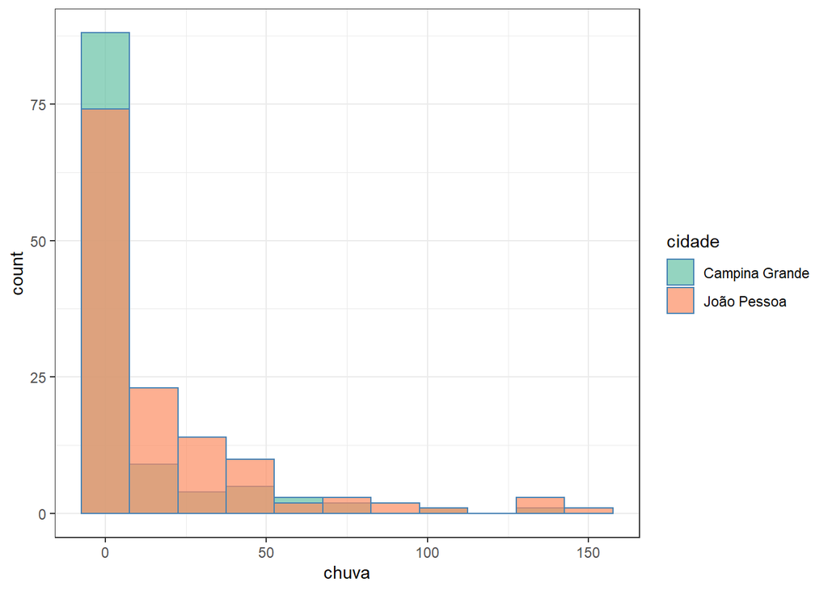

```r
ggplot(jan, aes(x = chuva, fill=cidade))+
    geom_histogram(binwidth =15, alpha =0.7, color = "steelblue", position = "identity")+
    scale_fill_brewer(palette="Set2")
```

1. Abril (outono):

```r
abril = climas %>% filter(mes == 4)

head(abril)
```

```
## # A tibble: 6 x 8
##   cidade         semana              tmedia  tmax  tmin chuva   mes   ano
##   <chr>          <dttm>               <dbl> <dbl> <dbl> <dbl> <dbl> <dbl>
## 1 Campina Grande 1994-04-03 00:00:00   24.7  29.5  19.5  52.8     4  1994
## 2 Campina Grande 1994-04-10 00:00:00   25.2  30.2  20.3   0.2     4  1994
## 3 Campina Grande 1994-04-17 00:00:00   24.6  29.8  19.6  17.4     4  1994
## 4 Campina Grande 1994-04-24 00:00:00   24.8  29.7  20.2   6.8     4  1994
## 5 Campina Grande 1995-04-02 00:00:00   25.5  31.3  19.9  17.9     4  1995
## 6 Campina Grande 1995-04-09 00:00:00   24.0  31.9  19.2  77.4     4  1995
```

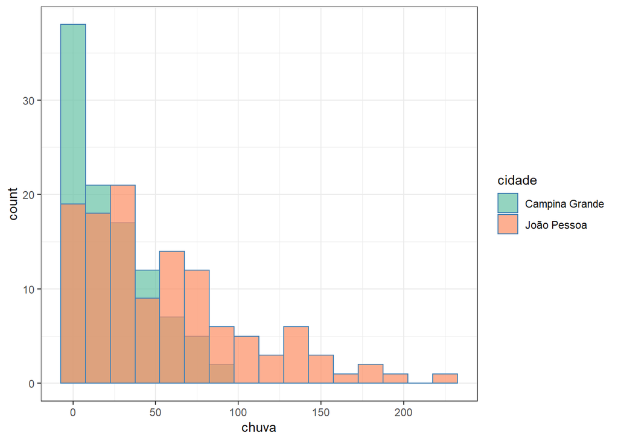

```r
ggplot(abril, aes(x = chuva, fill=cidade))+
    geom_histogram(binwidth =15, alpha =0.7, color = "steelblue", position = "identity")+
    scale_fill_brewer(palette="Set2")
```

1. Julho (inverno):

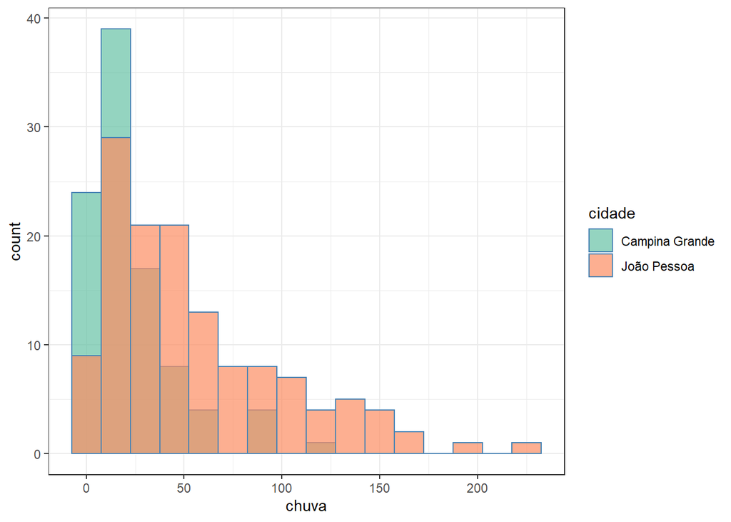

```r
jul = climas %>% filter(mes == 7)


ggplot(jul, aes(x = chuva, fill=cidade))+
    geom_histogram(binwidth =15, alpha =0.7, color = "steelblue", position = "identity")+
    scale_fill_brewer(palette="Set2")
```

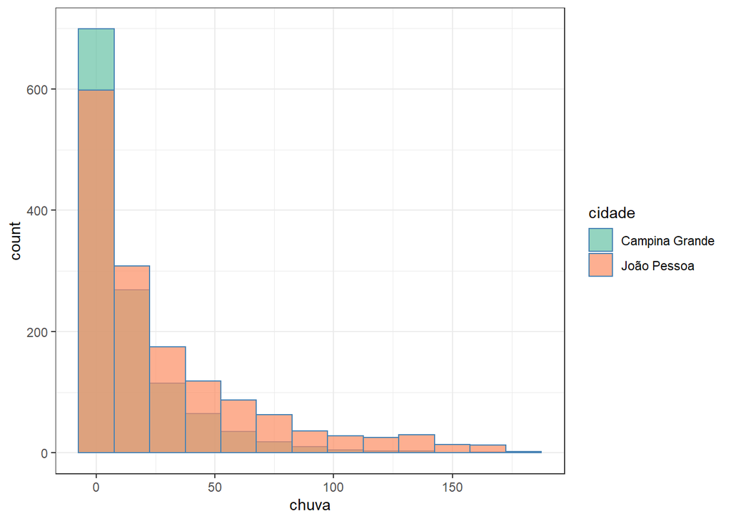

```r
outb = climas %>% filter(mes == 10)

ggplot(climas.corte, aes(x = chuva, fill=cidade))+
    geom_histogram(binwidth =15, alpha =0.7, color = "steelblue", position = "identity")+
    scale_fill_brewer(palette="Set2")
```